# Solution to Excercise 20150921

# Introduction

Affy microarray study to analyse liver disease.

# Loading the data

```r
setwd("~/Courses/BiostatLecture-2015/git-material/week2_21sep2015/exercise/")
  anno = read.table("SampleAnnotation.txt", as.is=TRUE, sep="\t", quote="",
                    row.names=1, header=TRUE)
```

Define sample name and colors

```r
samples = rownames(anno)
colors = rainbow(nrow(anno))
```

Define indicator variables

```r
isNorm = anno$TissueType == "norm"
isSick = anno$TissueType == "sick"
isAcute = anno$TissueType == "acute"
```

Load expression data

```r
x = read.table("expressiondata.txt", as.is=TRUE, sep="\t", quote="", row.names=1, header=TRUE, check.names = FALSE)
x = as.matrix(x)
```

Qualitatively compare the expression values of the first two samples

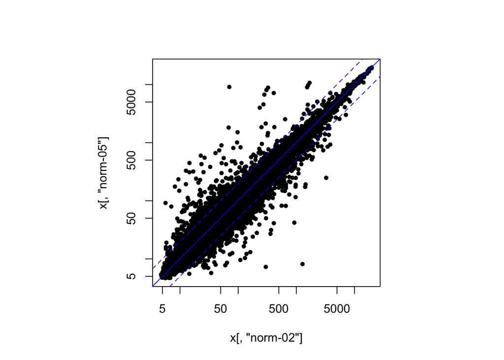

```r
par(pty="s")
plot(x[ , "norm-02"], x[, "norm-05"], log="xy", pch=20)
abline(0, 1, col="blue")
abline(log10(2), 1, col="blue", lty=2)
abline(-log10(2), 1, col="blue", lty=2)
```

# Checking the distribution of the intensities

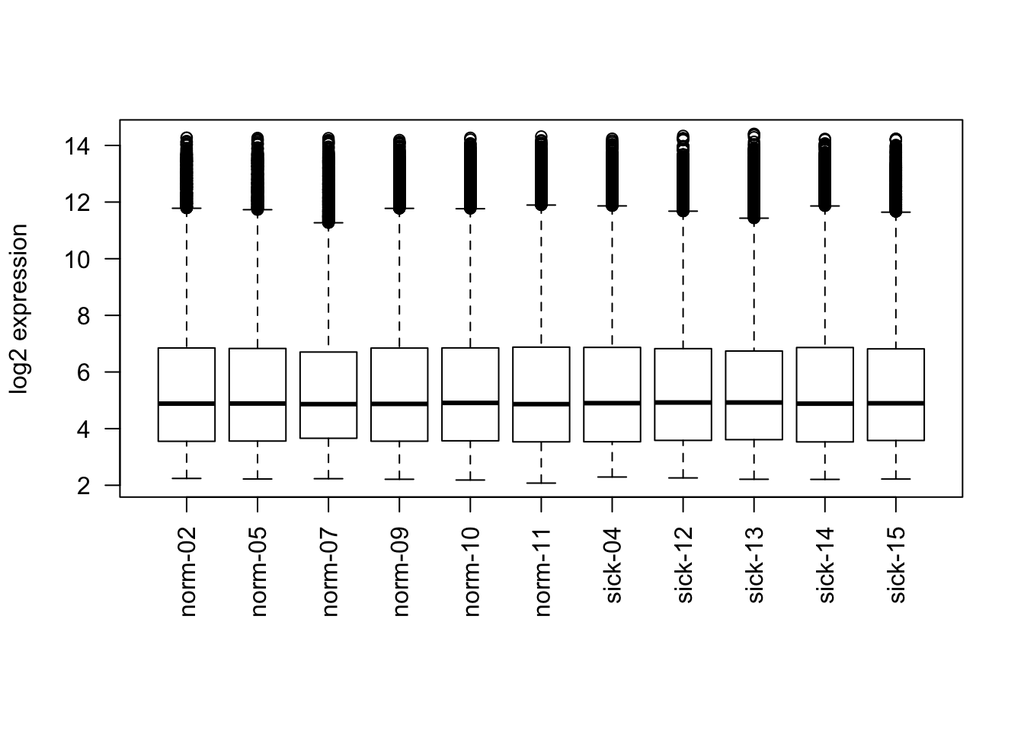

```r
par(mar=c(8, 4.1, 4.1, 2.1))
boxplot(log2(x), las=2, ylab="log2 expression")
```

# Checking the consistency of the replicates

```r
corrMatrix = cor(x)
signif(corrMatrix, digits=3)
```

```
##         norm-02 norm-05 norm-07 norm-09 norm-10 norm-11 sick-04 sick-12
## norm-02   1.000   0.981   0.962   0.967   0.958   0.982   0.910   0.885
## norm-05   0.981   1.000   0.963   0.978   0.975   0.980   0.938   0.927
## norm-07   0.962   0.963   1.000   0.984   0.969   0.968   0.940   0.925
## norm-09   0.967   0.978   0.984   1.000   0.985   0.970   0.954   0.945
## norm-10   0.958   0.975   0.969   0.985   1.000   0.974   0.955   0.950
## norm-11   0.982   0.980   0.968   0.970   0.974   1.000   0.926   0.905
## sick-04   0.910   0.938   0.940   0.954   0.955   0.926   1.000   0.983
## sick-12   0.885   0.927   0.925   0.945   0.950   0.905   0.983   1.000
## sick-13   0.882   0.916   0.925   0.938   0.939   0.901   0.976   0.974
## sick-14   0.957   0.980   0.973   0.990   0.988   0.968   0.962   0.960
## sick-15   0.862   0.886   0.930   0.932   0.940   0.897   0.939   0.943
##         sick-13 sick-14 sick-15
## norm-02   0.882   0.957   0.862
## norm-05   0.916   0.980   0.886
## norm-07   0.925   0.973   0.930
## norm-09   0.938   0.990   0.932
## norm-10   0.939   0.988   0.940
## norm-11   0.901   0.968   0.897
## sick-04   0.976   0.962   0.939
## sick-12   0.974   0.960   0.943
## sick-13   1.000   0.946   0.938
## sick-14   0.946   1.000   0.936
## sick-15   0.938   0.936   1.000
```

Visualize the correlation matrix

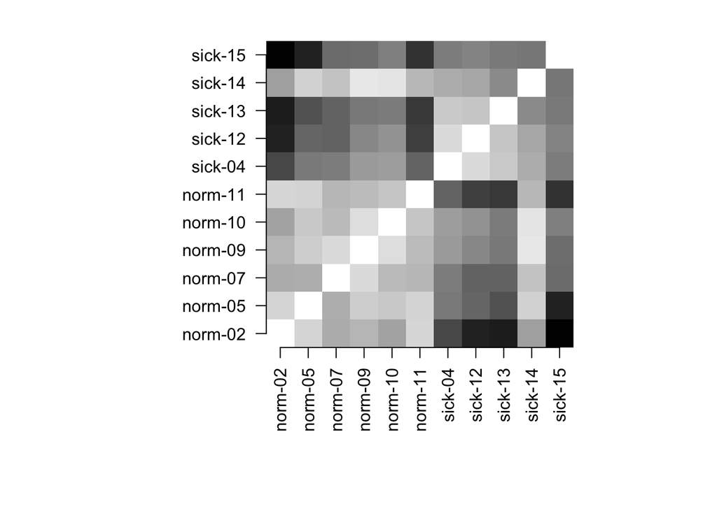

```r
par(mar=c(8,8,2,2), pty="s")
grayScale <- gray((1:256)/256)
image(corrMatrix, col=grayScale,  axes=FALSE)
axis(1, at=seq(from=0, to=1, length.out=length(samples)), labels=samples, las=2)
axis(2, at=seq(from=0, to=1, length.out=length(samples)), labels=samples, las=2)
```

# Sample Clustering

The sample clustering shows the similarities of the expression patterns of the samples in a tree. In order to compute the similarities of the samples one can use all genes or only a subset of the genes. When using all genes where is the risk that the absent genes drive the clustering of the samples. This is because in many studies the absent genes make up the majority of the measured genes. But those genes have a low intensity that is strongly influenced by the background signal measured on each chip and not by real gene expression

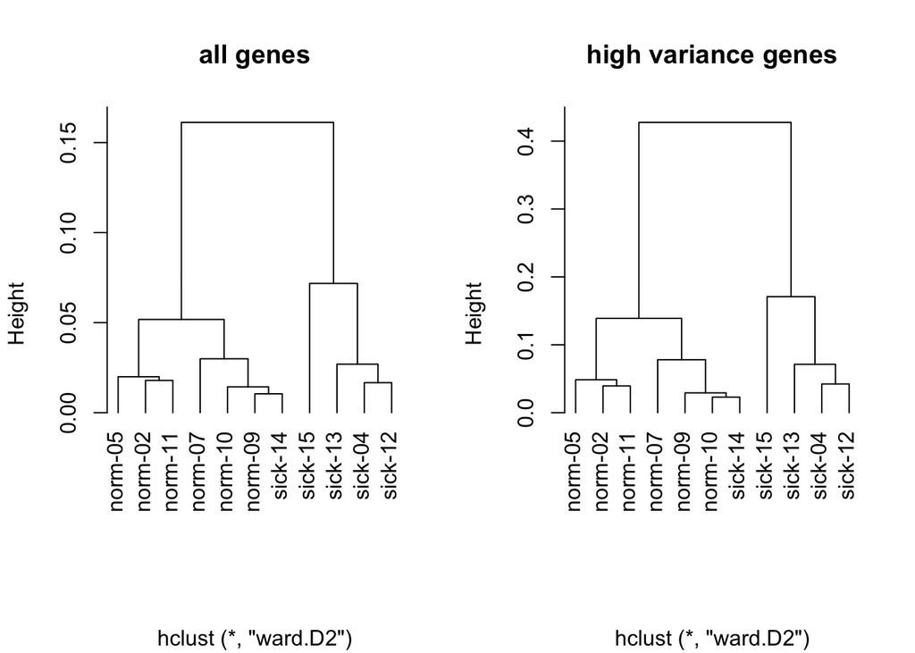

```r
x.sd = apply(x, 1, sd, na.rm=TRUE)
ord = order(x.sd, decreasing=TRUE)
highVarGenes = ord[1:500]
par(mfrow=c(1,2));
d = as.dist(1-cor(x));
c=hclust(d, method="ward.D2");
plot(c, hang=-0.1, main="all genes", xlab="")

d = as.dist(1-cor(x[highVarGenes, ]));
c=hclust(d, method="ward.D2");
plot(c, hang=-0.1, main="high variance genes", xlab="")
```

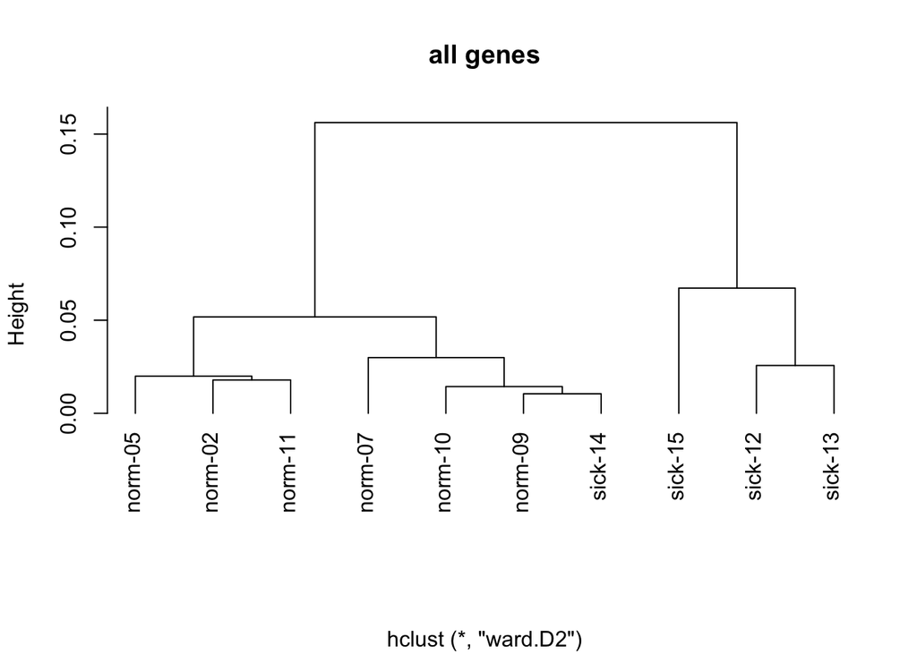

```r
sub = x[ , samples != "sick-04"]
d = as.dist(1-cor(sub));
c=hclust(d, method="ward.D2");
plot(c, hang=-0.1, main="all genes", xlab="")
```

# Quantile normalization

```r
require(limma)
```

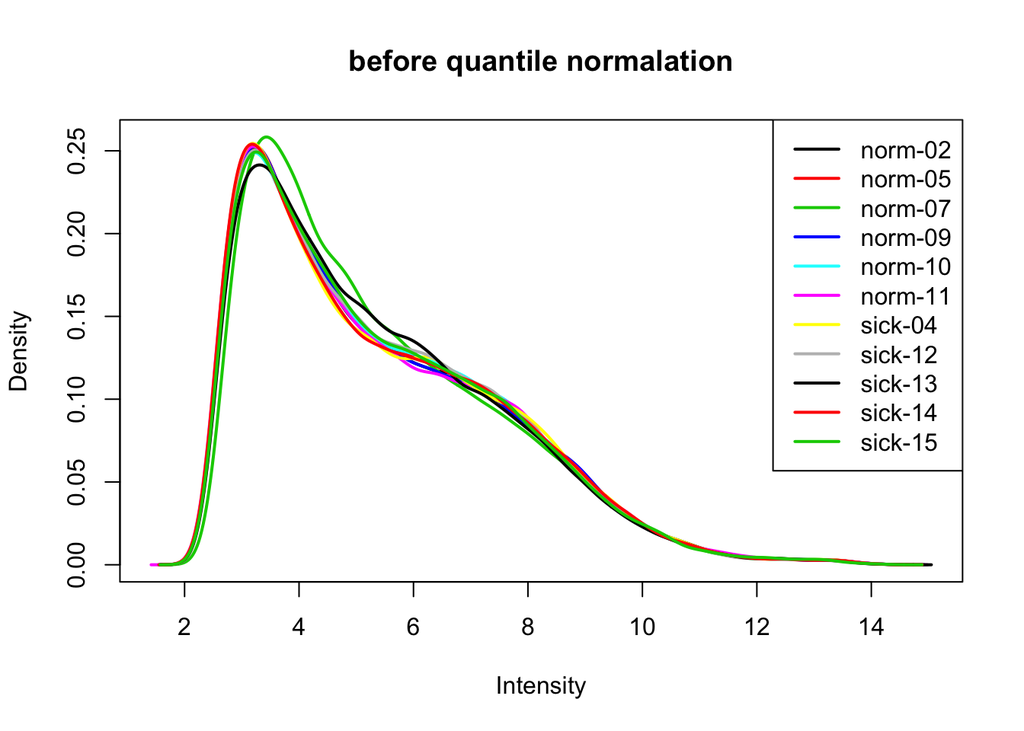

```r
xNorm = normalizeQuantiles(x)
plotDensities(log2(x), legend = "topright", main="before quantile normalation")
```

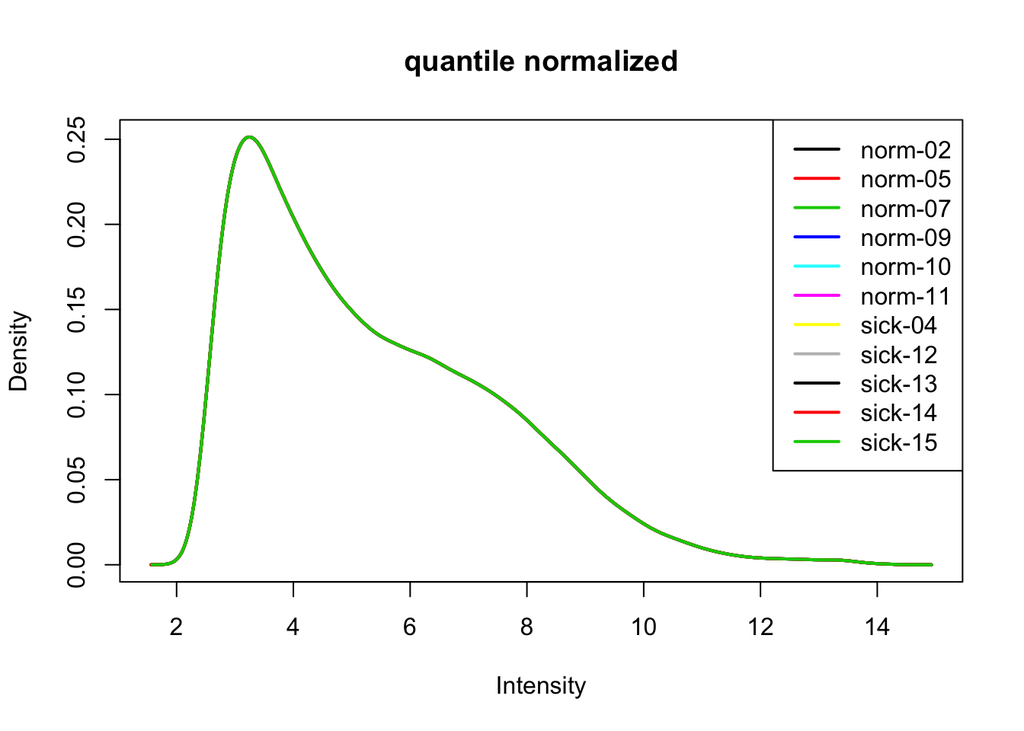

```r
plotDensities(log2(xNorm), legend = "topright", main="quantile normalized")
```

# Multi-dimensional scaling and Principal component analysis

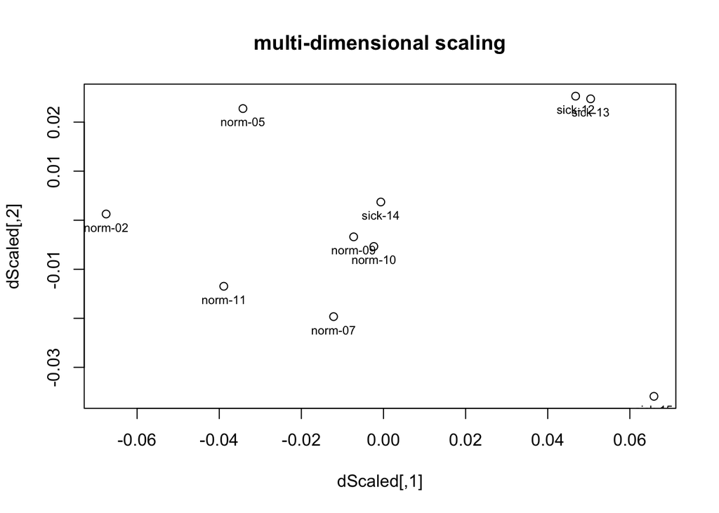

```r
dScaled <- cmdscale(d)
plot(dScaled, main="multi-dimensional scaling")
text(dScaled[ ,1],  dScaled[ ,2],labels =rownames(dScaled), pos=1, cex=0.7)
```

We are interested in the principle components for the samples that’s why we do transpose the matrix so that samples are in rows.

```r
pca <- prcomp(t(log2(x)))
summary(pca)
```

```
## Importance of components:
##                            PC1     PC2      PC3      PC4      PC5      PC6
## Standard deviation     60.5346 40.6954 27.05329 22.27228 20.64982 18.78549
## Proportion of Variance  0.4409  0.1993  0.08806  0.05969  0.05131  0.04246
## Cumulative Proportion   0.4409  0.6402  0.72825  0.78794  0.83925  0.88171
##                            PC7     PC8     PC9     PC10      PC11
## Standard deviation     17.4895 15.8423 14.8973 14.29434 2.357e-13
## Proportion of Variance  0.0368  0.0302  0.0267  0.02459 0.000e+00
## Cumulative Proportion   0.9185  0.9487  0.9754  1.00000 1.000e+00
```